```r
library(forecast)
```

## Data setup

```r
data = read.csv("portal_timeseries.csv", stringsAsFactors = FALSE)
head(data)
```

```
##   X     NDVI rain  rodents      date
## 1 1 0.181375 39.3 445.8643 3/15/1992
## 2 2 0.243400 29.4 491.1766 4/15/1992
## 3 3 0.218500 20.4 384.7876 5/15/1992
## 4 4 0.217700  0.0 439.2565 6/15/1992
## 5 5 0.207800 82.6 391.8683 7/15/1992
## 6 6 0.220150 19.1 430.8875 8/15/1992
```

```r
NDVI_ts = ts(data$NDVI, start = c(1992, 3), end = c(2014, 11), frequency = 12)
rain_ts = ts(data$rain, start = c(1992, 3), end = c(2014, 11), frequency = 12)
```

## Plot the data

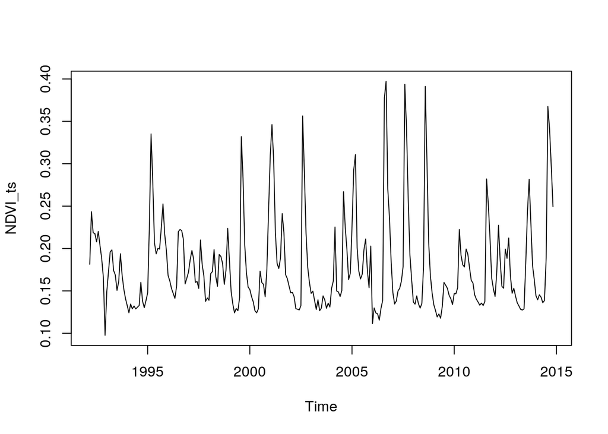

```r
plot(NDVI_ts)
```

## White noise model

- Most basic time-series model
- Normally distributed data w/fixed mean and variance
- No change time-series is just random samples

> y = c + e_t, where e_t ~ N(0, sigma)

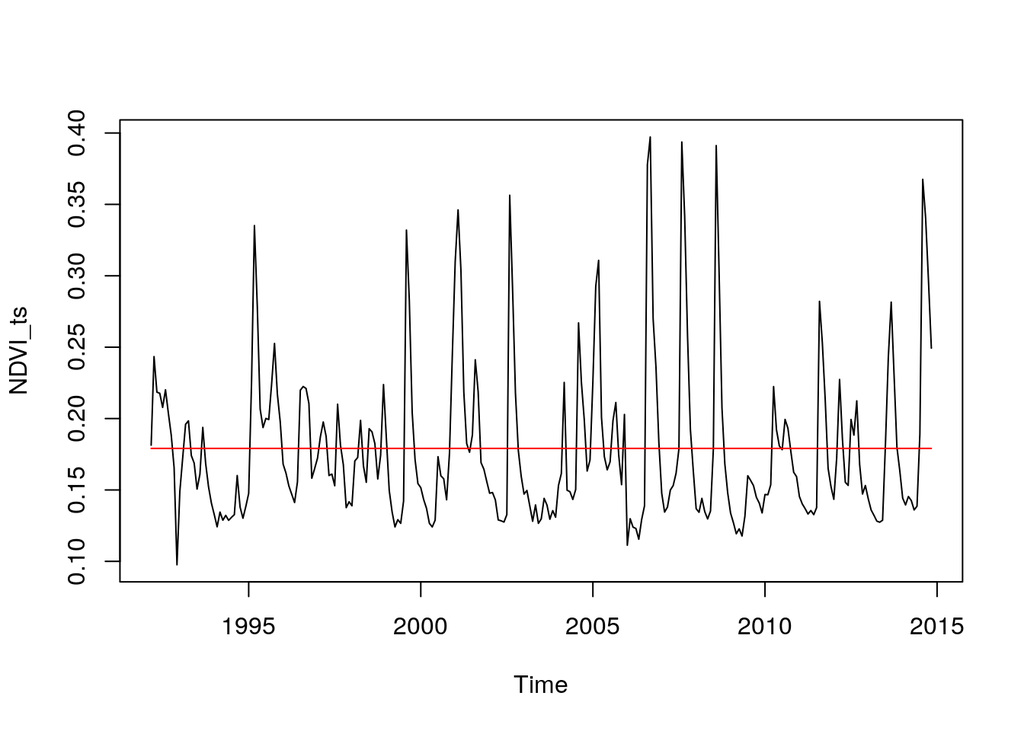

```r
avg_model = meanf(NDVI_ts)
plot(NDVI_ts)
lines(fitted(avg_model), col = 'red')
```

```r
summary(avg_model)
```

```
##
## Forecast method: Mean
##
## Model Information:
## $mu
## [1] 0.179087
##
## $mu.se
## [1] 0.003395312
##
## $sd
## [1] 0.05609977
##
## $bootstrap
## [1] FALSE
##
## $call
## meanf(y = NDVI_ts)
##
##
## Error measures:
##                        ME       RMSE        MAE       MPE     MAPE
## Training set 9.354322e-18 0.05599693 0.04117482 -7.551363 22.44452
##                   MASE      ACF1
## Training set 0.8523097 0.6560182
##
## Forecasts:
##          Point Forecast     Lo 80     Hi 80   Lo 95     Hi 95
## Dec 2014       0.179087 0.1068854 0.2512887 0.06844 0.2897341
## Jan 2015       0.179087 0.1068854 0.2512887 0.06844 0.2897341
## Feb 2015       0.179087 0.1068854 0.2512887 0.06844 0.2897341
## Mar 2015       0.179087 0.1068854 0.2512887 0.06844 0.2897341
## Apr 2015       0.179087 0.1068854 0.2512887 0.06844 0.2897341
## May 2015       0.179087 0.1068854 0.2512887 0.06844 0.2897341
## Jun 2015       0.179087 0.1068854 0.2512887 0.06844 0.2897341
## Jul 2015       0.179087 0.1068854 0.2512887 0.06844 0.2897341
## Aug 2015       0.179087 0.1068854 0.2512887 0.06844 0.2897341
## Sep 2015       0.179087 0.1068854 0.2512887 0.06844 0.2897341
```

## Auto-regressive model

- But we know this isn’t right

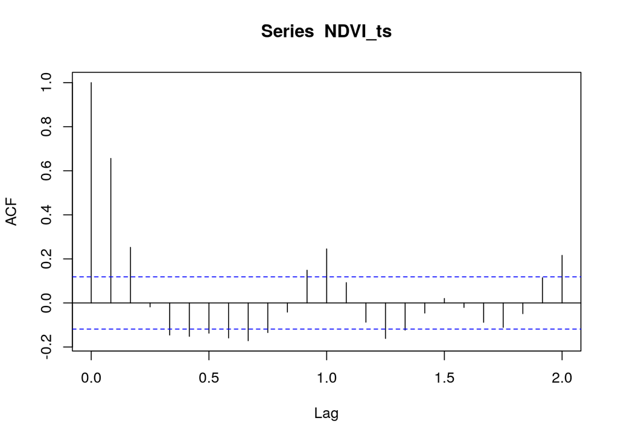

```r
acf(NDVI_ts)
```

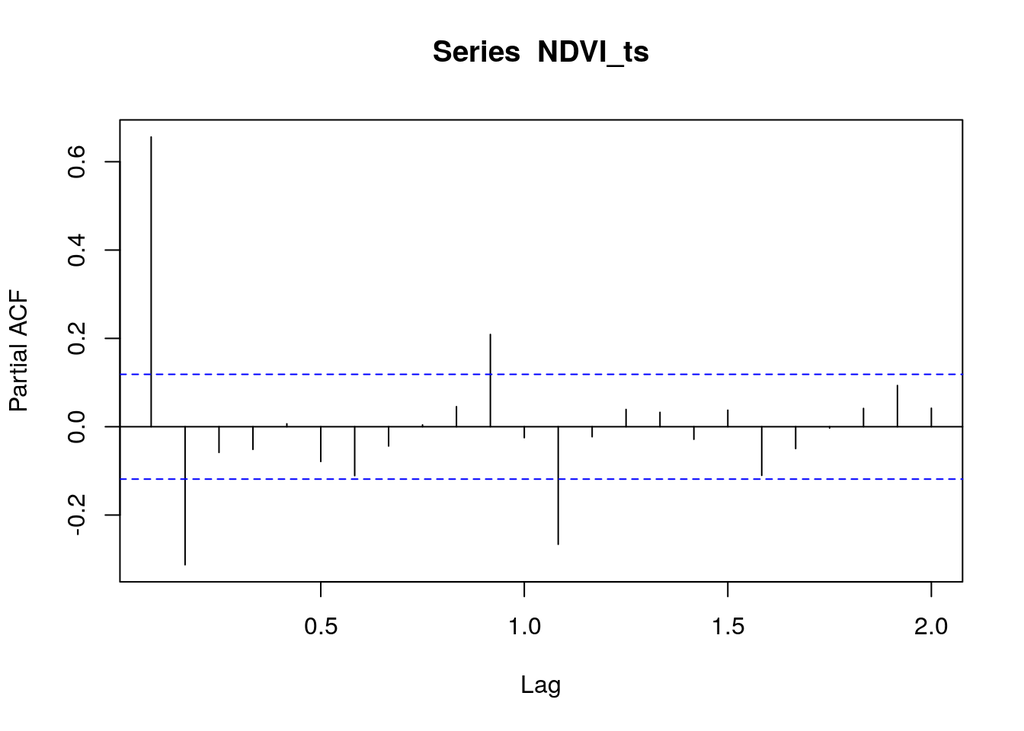

```r
pacf(NDVI_ts)
```

- Build a model that takes this autocorrelation into account
- “Autoregressive model”"
- Predict value based on previous states in time-series

> y_t = c + b1 * y_t-1 + b2 * y_t-2 … + e_t
- Does this remind you of a biological model?
  - This model is bascially a Gompertz population model if y is log(N)
- ARIMA: autoregressive, integrated, moving average
- Fit using `Arima()` function

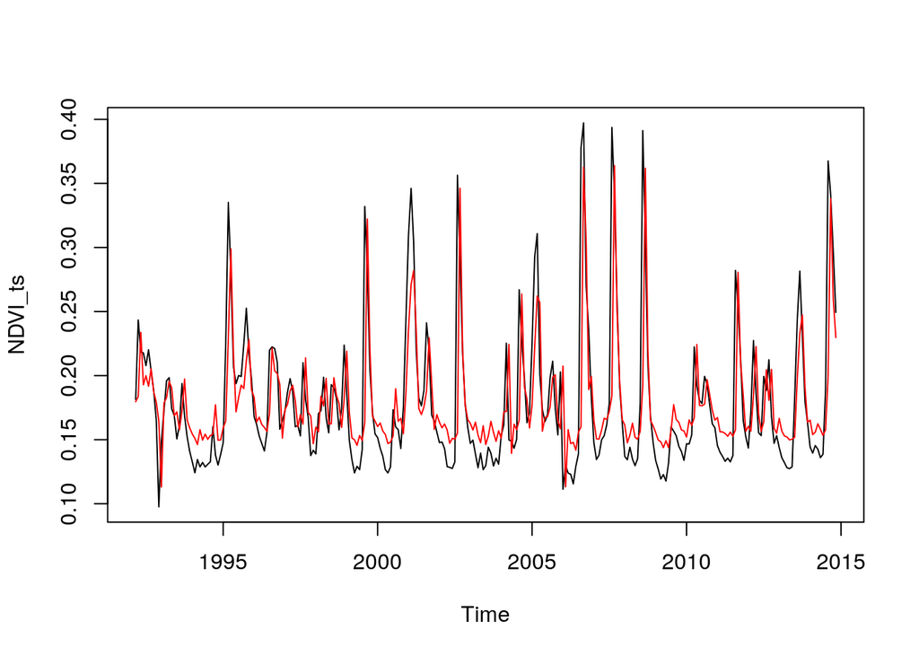

```r
arima_model = Arima(NDVI_ts, c(2, 0, 0))
plot(NDVI_ts)
lines(fitted(arima_model), col = 'red')
```

```r
summary(arima_model)
```

```
## Series: NDVI_ts
## ARIMA(2,0,0) with non-zero mean
##
## Coefficients:
##          ar1      ar2    mean
##       0.8612  -0.3123  0.1790
## s.e.  0.0575   0.0580  0.0054
##
## sigma^2 estimated as 0.001624:  log likelihood=490.43
## AIC=-972.87   AICc=-972.72   BIC=-958.43
##
## Training set error measures:
##                        ME       RMSE        MAE       MPE     MAPE
## Training set 5.609113e-05 0.04008277 0.02521092 -3.679855 13.25905
##                   MASE        ACF1
## Training set 0.5218606 -0.01609386
```

- Check fit

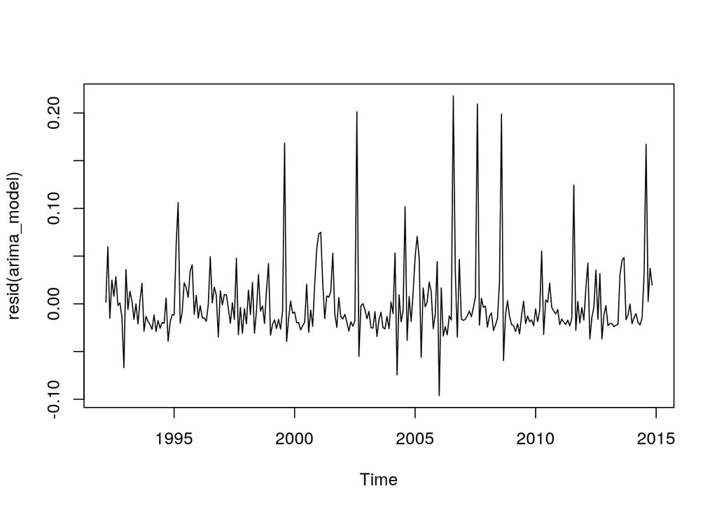

```r
plot(resid(arima_model))
```

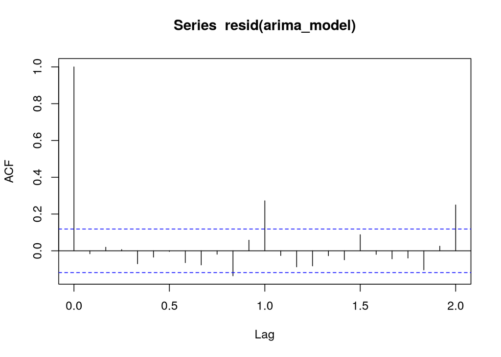

```r
acf(resid(arima_model))
```

- Autocorrelation at 1 and 2 years
- Seasonal signal
- Seasonal component is modeled in the same way, but in 1 full season steps

> y_t = constant + b1 * y_t-1 + b2 * yt_2 + b3 * y_t-12 + b4 * y_t-24 + e_t

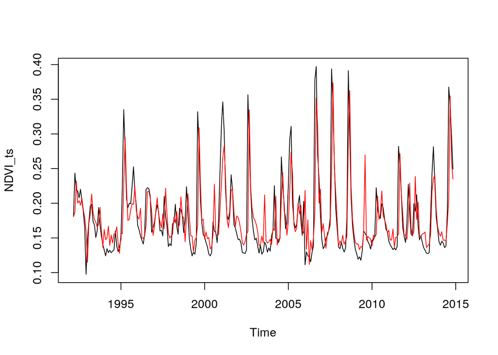

```r
seasonal_arima_model = Arima(NDVI_ts, c(2, 0, 0), seasonal = c(2, 0, 0))
plot(NDVI_ts)
lines(fitted(seasonal_arima_model), col = 'red')
```

```r
summary(seasonal_arima_model)
```

```
## Series: NDVI_ts
## ARIMA(2,0,0)(2,0,0)[12] with non-zero mean
##
## Coefficients:
##          ar1      ar2    sar1    sar2    mean
##       0.8425  -0.2167  0.2506  0.2156  0.1802
## s.e.  0.0592   0.0612  0.0604  0.0604  0.0107
##
## sigma^2 estimated as 0.001419:  log likelihood=508.72
## AIC=-1005.44   AICc=-1005.13   BIC=-983.79
##
## Training set error measures:
##                        ME      RMSE        MAE       MPE     MAPE
## Training set 3.658684e-05 0.0373203 0.02346926 -3.107913 12.26968
##                   MASE      ACF1
## Training set 0.4858086 -0.018553
```

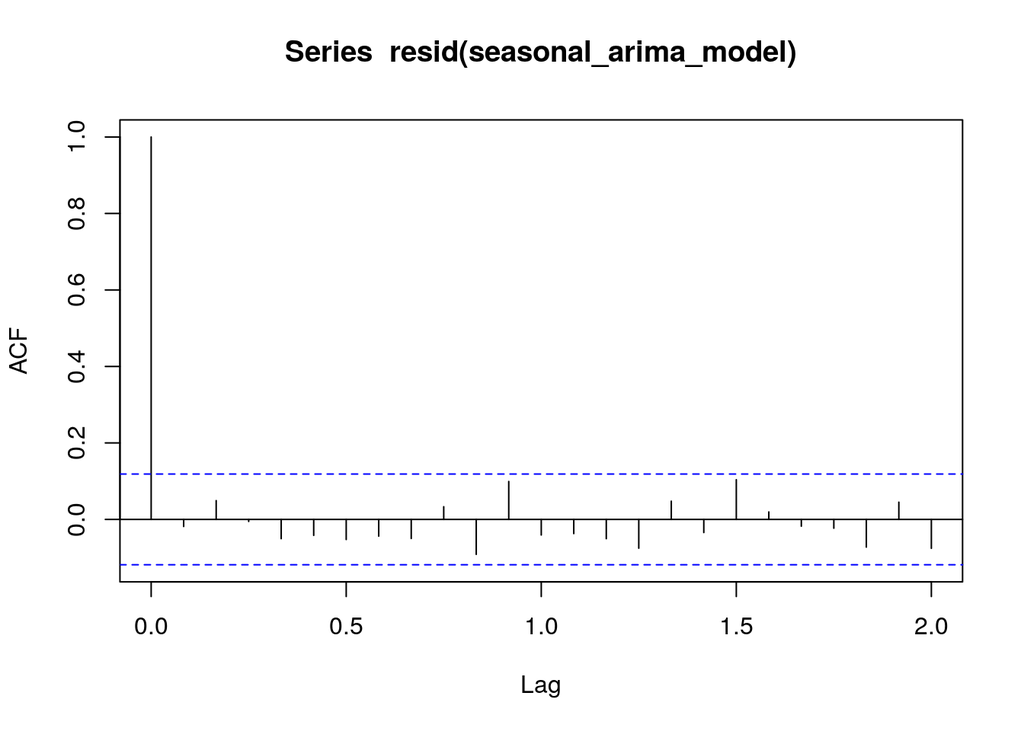

```r
acf(resid(seasonal_arima_model))
```

> CLASS EXERCISE: Build seasonal and non-seasonal ARIMAs for the precipitation data

## Automating fits

- Iterative manual fitting is great, but
  - Often want “best” model
  - Fit lots of models at once
- Fit many possible values of seasonal, AR, differencing, and MA, and pick the best
- Unit root tests, minimization of the AICc and MLE

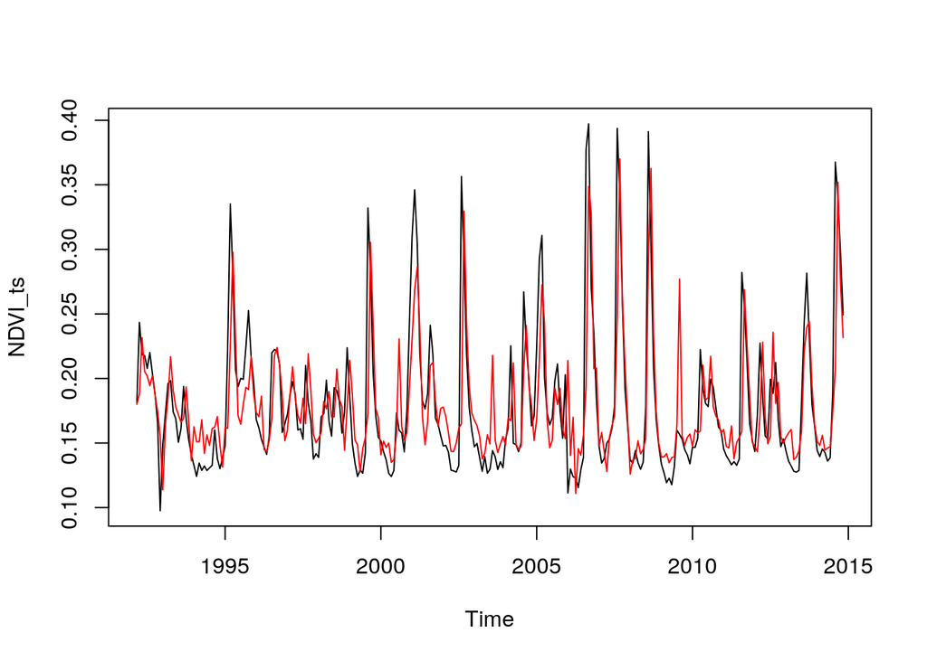

```r
arima_model = auto.arima(NDVI_ts)
plot(NDVI_ts)
lines(fitted(arima_model), col='red')
```

```r
summary(arima_model)
```

```
## Series: NDVI_ts
## ARIMA(2,0,1)(2,0,0)[12] with non-zero mean
##
## Coefficients:
##          ar1      ar2      ma1    sar1    sar2    mean
##       1.3820  -0.5840  -0.5830  0.2563  0.2267  0.1792
## s.e.  0.1991   0.1244   0.2317  0.0604  0.0600  0.0085
##
## sigma^2 estimated as 0.001402:  log likelihood=510.69
## AIC=-1007.38   AICc=-1006.96   BIC=-982.11
##
## Training set error measures:
##                        ME       RMSE        MAE       MPE     MAPE
## Training set 0.0001164612 0.03703093 0.02377166 -3.005846 12.48021
##                   MASE       ACF1
## Training set 0.4920681 0.01298545
```

- MA component in best model
- What are those other two numbers
  - Moving average: autocorrelated errors
  - Differencing: handles strong one-step autocorrelations, like trends
- Can use `seasonal = FALSE` to skip seasonal signal

## Incorporating external co-variates

- Often want external predictors in our model
- Do this like we would in normal regression
- Add values of x and associated coefficient to model

> y_t = c + b1 * y_t-1 + b2 * x_t … + e_t

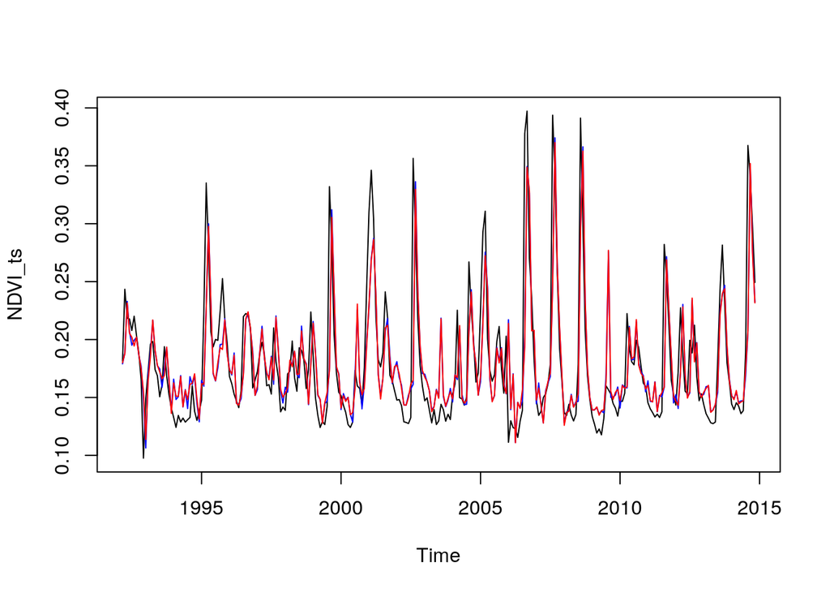

```r
rain_arima_model = auto.arima(NDVI_ts, xreg = rain_ts)
plot(NDVI_ts)
lines(fitted(rain_arima_model), col = 'blue')
lines(fitted(arima_model), col = 'red')
```